# A Deep Dive into Ford GoBike System Data

## by Ahmed Sabry

## Investigation Overview

> We'll check one of the main feature of interest which is the trip duration and we'll look into it and its relationship with some other features as well

## Dataset Overview

> This dataset includes information about individual rides made in a bike-sharing system covering the greater San Francisco Bay area in December 2019.

> It has **150,102 rows** and **14 columns** Each trip is anonymized and includes:
> - Trip Duration (seconds)
> - Start Time and Date
> - End Time and Date
> - Start Station ID
> - Start Station Name
> - Start Station Latitude
> - Start Station Longitude
> - End Station ID
> - End Station Name
> - End Station Latitude
> - End Station Longitude
> - Bike ID
> - User Type (Subscriber or Customer – “Subscriber” = Member or “Customer” = Casual)
> - Bike Share for all trip

## The histogram of trip duration in seconds

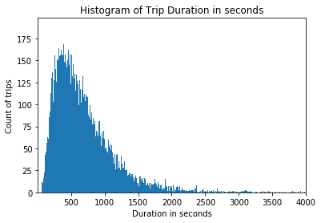

```python
bins = np.arange(df["duration_sec"].min(), df["duration_sec"].max()+1,1)
plt.hist(data=df, x="duration_sec", bins=bins)
plt.title("Histogram of Trip Duration in seconds")
plt.xlabel("Duration in seconds")
plt.ylabel("Count of trips")
plt.xlim([6,4000])
plt.show();
```

## Trip duration over weekdays

> We can see that trips have most of the trips under 2000 seconds over all the week days. There are some differences from one day to another.

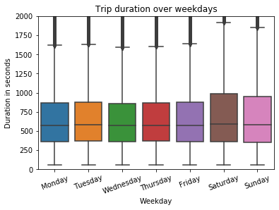

```python
#We'll check the trip duration in seconds over the week days
sb.boxplot(data = df , x = 'week_day' , y = 'duration_sec')
plt.title('Trip duration over weekdays')
plt.xlabel('Weekday')
plt.ylabel('Duration in seconds')
plt.ylim([0,2000])
plt.xticks(rotation=20)
plt.show()
```

## Trip Duration over different wekdays and day hours

> We can see more shade of violent rides which reflects trips very late from 20:00 to 1:00 at the zone of short trips.

> While Blue-scale trips which reflects the mid-day trips are higher in duration.

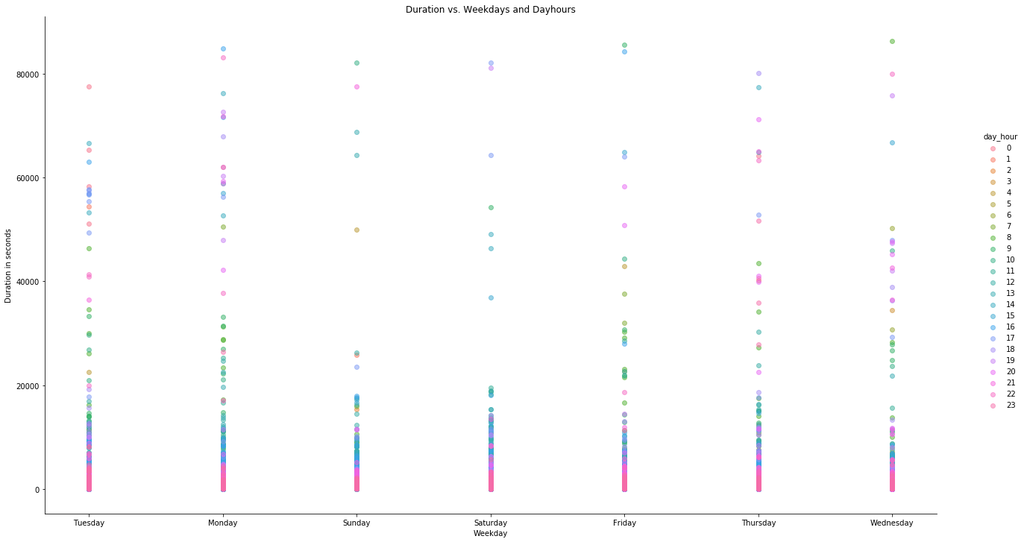

```python
grid = sb.FacetGrid(data =  df, hue = 'day_hour', height = 10)
grid.map(plt.scatter, 'week_day','duration_sec', alpha = 0.5)
plt.title('Duration vs. Weekdays and Dayhours')
plt.xlabel('Weekday')
plt.ylabel('Duration in seconds')
grid.add_legend()
plt.gcf().set_size_inches(20, 10)
plt.show();
```